# Random Numbers in NumPy

# Visualization of Chi Square Distribution

[output not shown]

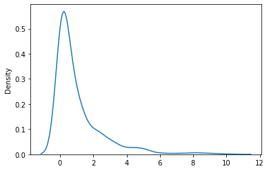

```python
from numpy import random
import matplotlib.pyplot as plt
import seaborn as sns

sns.distplot(random.chisquare(df=1, size=1000), hist=False)

plt.show()
```

[output not shown]

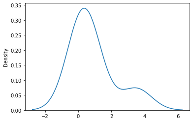

```python
from numpy import random
import matplotlib.pyplot as plt
import seaborn as sns

sns.distplot(random.chisquare(df=1, size=(2,3)), hist=False)

plt.show()
```

[output not shown]

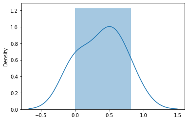

```python
from numpy import random
import matplotlib.pyplot as plt
import seaborn as sns

sns.distplot(random.chisquare(df=1, size=(2,3)), hist=True,kde=True)

plt.show()
```

[output not shown]

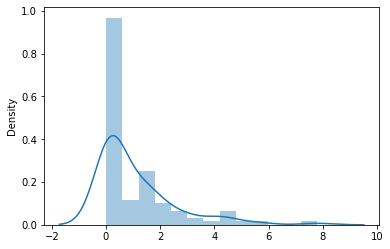

```python
from numpy import random
import matplotlib.pyplot as plt
import seaborn as sns

sns.distplot(random.chisquare(df=1, size=100), hist=True,kde=True)

plt.show()
```

# Rayleigh Distribution

Rayleigh distribution is used in signal processing.

It has two parameters:

scale - (standard deviation) decides how flat the distribution will be default 1.0).

size - The shape of the returned array.

Draw out a sample for rayleigh distribution with scale of 2 with size 2x3:

```python
from numpy import random

x = random.rayleigh(scale=2, size=(2, 3))

print(x)
```

```
[[2.63528255 3.61189951 3.37247381]
 [2.80952329 2.86384444 1.2849626 ]]
```

```python
from numpy import random

x = random.rayleigh()

print(x)
```

```
0.12224123613625315
```

```python
from numpy import random

x = random.rayleigh(size=10)

print(x)
```

```
[0.59368204 0.60367785 1.33531509 0.73861241 1.04330633 0.70456431
 1.10153078 0.79024545 0.88721112 0.62288384]
```

```python
from numpy import random

x = random.rayleigh(scale=20, size=10)

print(x)
```

```
[37.54830419  9.15235262 15.26092976 43.40539756 49.51563612 25.78472082
 35.73864678 23.58376348 54.74674322 13.95724384]
```

# Visualization of Rayleigh Distribution

[output not shown]

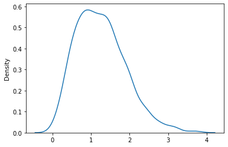

```python
from numpy import random
import matplotlib.pyplot as plt
import seaborn as sns

sns.distplot(random.rayleigh(size=1000), hist=False)

plt.show()
```

[output not shown]

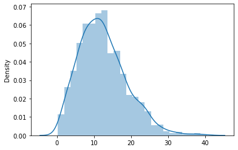

```python
from numpy import random
import matplotlib.pyplot as plt
import seaborn as sns

sns.distplot(random.rayleigh(scale=10,size=1000), hist=True,kde=True)

plt.show()
```

[output not shown]

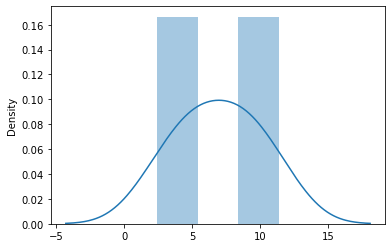

```python
from numpy import random
import matplotlib.pyplot as plt
import seaborn as sns

sns.distplot(random.rayleigh(scale=5,size=(2,3)), hist=True,kde=True)

plt.show()
```

# Similarity Between Rayleigh and Chi Square Distribution

At unit stddev(standard deviation) the and 2 degrees of freedom rayleigh and chi square represent the same distributions.

# Pareto Distribution

A distribution following Pareto's law i.e. 80-20 distribution (20% factors cause 80% outcome).

It has two parameter:

a - shape parameter.

size - The shape of the returned array.

Draw out a sample for pareto distribution with shape of 2 with size 2x3:

```python
from numpy import random

x = random.pareto(a=2, size=(2, 3))

print(x)
```

```
[[ 0.98588706 20.80188094  0.27304521]
 [ 0.11551158  0.05911756  0.30874412]]
```

```python
from numpy import random

x = random.pareto(a=20, size=10)

print(x)
```

```
[0.07453907 0.04041786 0.00992002 0.12778663 0.00367064 0.01792268
 0.00676592 0.04099634 0.01691997 0.0383904 ]
```

```python
from numpy import random

x = random.pareto(a=5)

print(x)
```

```
0.15010779886495618
```

# Visualization of Pareto Distribution

[output not shown]

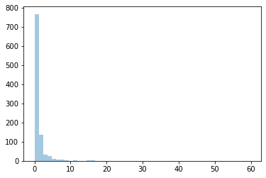

```python
from numpy import random
import matplotlib.pyplot as plt
import seaborn as sns

sns.distplot(random.pareto(a=2, size=1000),hist=True, kde=False)

plt.show()
```

[output not shown]

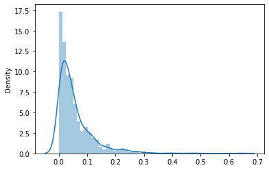

```python
from numpy import random
import matplotlib.pyplot as plt
import seaborn as sns

sns.distplot(random.pareto(a=20, size=1000),hist=True, kde=True)

plt.show()
```

# Zipf Distribution

Zipf distritutions are used to sample data based on zipf's law.

Zipf's Law: In a collection the nth common term is 1/n times of the most common term. E.g. 5th common word in english has occurs nearly 1/5th times as of the most used word.

It has two parameters:

a - distribution parameter.

size - The shape of the returned array.

Draw out a sample for zipf distribution with distribution parameter 2 with size 2x3:

```python
from numpy import random

x = random.zipf(a=2, size=(2, 3))

print(x)
```

```
[[1 1 1]
 [2 1 5]]
```

```python
from numpy import random

x = random.zipf(a=30, size=10)

print(x)
```

```
[1 1 1 1 1 1 1 1 1 1]
```

# Visualization of Zipf Distribution

Sample 1000 points but plotting only ones with value < 10 for more meaningful chart.

[output not shown]

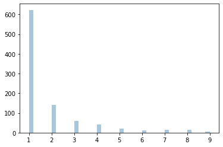

```python
from numpy import random
import matplotlib.pyplot as plt
import seaborn as sns

x = random.zipf(a=2, size=1000)
sns.distplot(x[x<10], kde=False)

plt.show()
```

[output not shown]

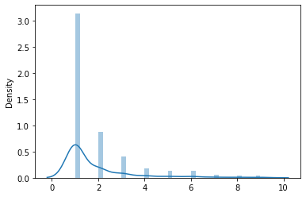

```python
from numpy import random
import matplotlib.pyplot as plt
import seaborn as sns

x = random.zipf(a=2, size=1000)
sns.distplot(x[x<10], hist=True,kde=True)

plt.show()
```